# Part II - Données du système Ford GoBike

### Par Darnel KOUA

## Aperçu de l’enquête

Dans le cadre de ce projet, on voulais examiner les caractéristiques du système de partage de vélos, examiner la durée des voyages, la période où s'effectue ses voyages, les stations les plus populaires.

## Aperçu de l’ensemble de données

Les données comportaient 183412 observations sur les trajets individuels effectués dans un système de partage de vélos couvrant la grande région de la baie de San Francisco. Il y'avait comme variables la durée en seconde du voyage, le sexe des membres, l'année de naissance, le type d'utilisateur et bien d'autres variables. En raison des valeurs manquantes et des données incohérentes, 14241 observations ont été rétirées.

## Distribution de la durée des vayages

Dans l'ensemble la distribution de la durée des voyages est étalée vers la droite c'est-àdire les petits temps de trajet sont fréquent plus que les longs temps de trajet. Le temps moyen d'un trajet est d'environ 703 secondes soit 12 minutes environ.

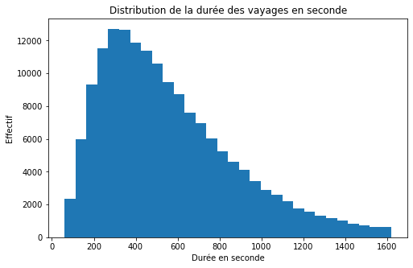

## Distribution de l'année de naissance

Pour ce qui est de l'âge on constate une asymétrie droite, c'est-à-dire les individus moins âgés dans notre population sont plus fréquent à voyager en vélo que les individus plus agés.

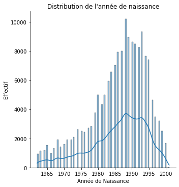

## Repartion par heure et par mois des departs de vélos

Nos observations concernent uniquement le mois de février 2019, et pendant ce mois, on observe une augmentation progressive du nombre de voyage pendant les jours ordinaires et une baisse les week-ends. Les heures préférées des voyageurs sont pour la plupart le matin à 8h et le soir vers 17h, 18h.

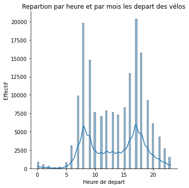

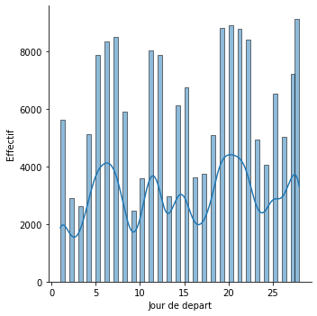

## Les stations les plus populaire

Pour des soucis de visibiliter nous avons choisi de ne représenter que les 20 premières stations de depart et d'arrivée et il apparait que les stations les plus populaires sont: San Franscisco Caltrain, Market St at 10th St, Montgomery, Powell St BART Station que ça soit pour les satitions depart ou l'arrivée.

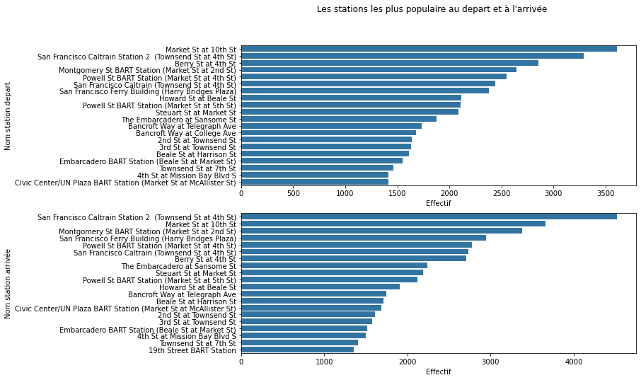

## Distribution de la log_durée de voyage et année de naissance par partage de vélo

Les gens qui ont partagé le vélo sont un peu plus jeune que les gens qui n'ont pas fait le partage de vélo, on peut donc penser que l'âge diminue avec le fait de partager le vélo pour un voyage. On dira qu'il y'a une dependance entre les variables année de naissance et partage de vélo. Par contre il n'y a pas de liaison entre la variable partage de vélo et durée du voyage.

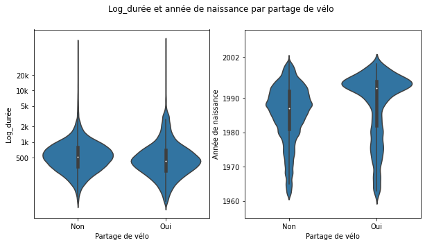